# Final Project

Hanwen Luo

12/4/2019

# Background

- Historically, CO2 emissions have been primarily driven by increasing fuel consumption, which has, and continues to be, a fundamental pillar of economic growth. However, the relationship between CO2 emissions and economic growth has been well established. There might be some more specific detailed factors that drive GDP growth and in the meantime influence CO2 emission.
- For these detailed factors, I am looking at access to electricity, urban population, rural population, agricultural industry value, investment in environment related industries such as water, energy and transportation and so on. These factors are related to economic growth and also affect the environment.
- The purpose of this analysis is to see among these variables I collected what might be the real important economical variable that is driving CO2 emissions.

# Methods considered and used and rationale

- Data Wrangling

  The raw data collected for this project are ‘dirty’ and have different forms. Also, there are several datasets that need to be combined. So functions like ‘select’, ‘gather’, ‘arrange’, ‘bind_cols’ are used.
- Data Visualization

  When it comes to the overview of variables before doing anything abd which model fits the best and variable importance, graphs are more straightforward.
- Machine Learning (regression) (variable importance)

  Since the goal is to explore the relationship between outcome variable (CO2 emission) and predictors, regression is necessary. In addition, it is important to know which variable is most important in this process.

# Overview of some variables

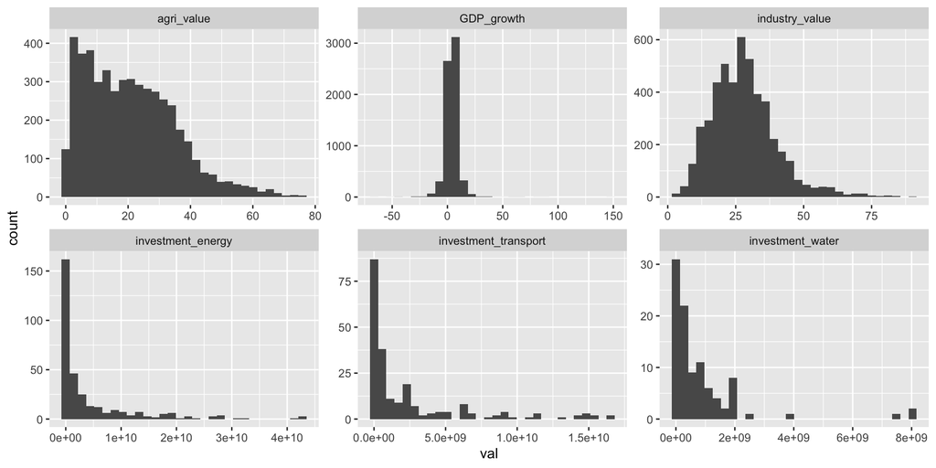

# Preliminary results (regression:RMSE)

Use three models and then compare: Linear, K-Nearest Neighbors, Random Forest

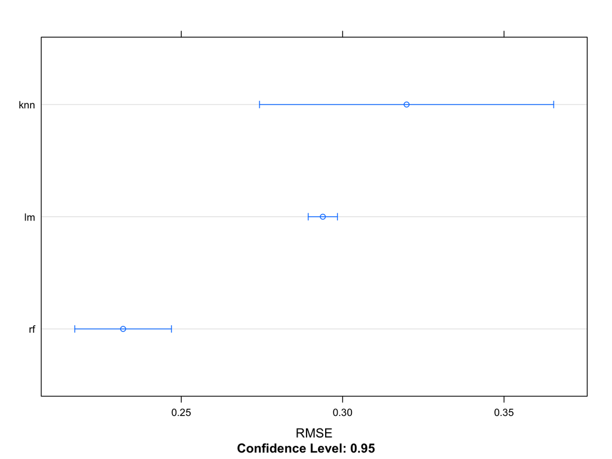

# Preliminary results (regression:Rsquared,MSE)

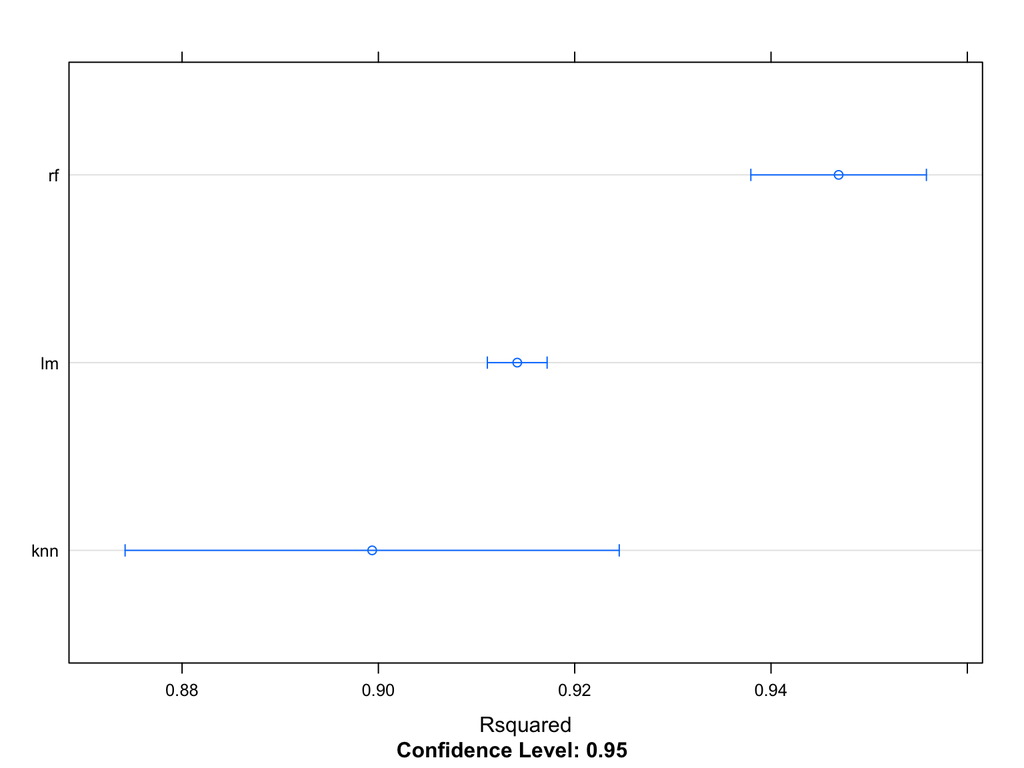

The random forest model performed the best.

MSE:

```
## [1] 0.2407058
```

# Preliminary results (variable importance)

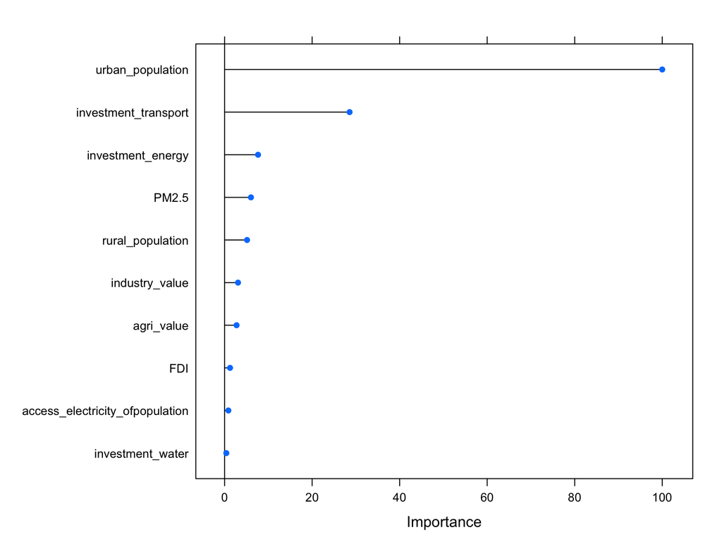

The most important 3 variables are:

urban population, investment in transportation, investment in energy

# Lesson learned and challenges

- LESSON

Random Forest is the best model (highest R^2 and lowest RMSE, mse=0.24)

The most important 3 variables are: urban population, investment in transportation, investment in energy. (urbanization and investment in enviornment related industries strongly affects CO2 emission)

- CHALLENGE

Too many useless observations (non-country, needed to be deleted)

Too many NAs. (focus on countries have enough data)

Variables have different scales. (change scales)